# after_review

## Analyzing borrowers’ risk of defaulting

Your project is to prepare a report for a bank’s loan division. You’ll need to find out if a customer’s marital status and number of children has an impact on whether they will default on a loan. The bank already has some data on customers’ credit worthiness.

Your report will be considered when building a **credit scoring** of a potential customer. A **credit scoring** is used to evaluate the ability of a potential borrower to repay their loan.

### Step 1. Open the data file and have a look at the general information.

```python
import pandas as pd
import numpy as np
from collections import Counter
import seaborn as sns
import matplotlib.pyplot as plt

df = pd.read_csv('/datasets/credit_scoring_eng.csv')
df.head(5)
```

|  | children | days_employed | dob_years | education | education_id | family_status | family_status_id | gender | income_type | debt | total_income | purpose |
| --- | --- | --- | --- | --- | --- | --- | --- | --- | --- | --- | --- | --- |
| 0 | 1 | -8437.673028 | 42 | masters degree | 0 | married | 0 | F | employee | 0 | 253875.639453 | purchase of the house |
| 1 | 1 | -4024.803754 | 36 | secondary education | 1 | married | 0 | F | employee | 0 | 112080.014102 | car purchase |
| 2 | 0 | -5623.422610 | 33 | Secondary Education | 1 | married | 0 | M | employee | 0 | 145885.952297 | purchase of the house |
| 3 | 3 | -4124.747207 | 32 | secondary education | 1 | married | 0 | M | employee | 0 | 267628.550329 | supplementary education |
| 4 | 0 | 340266.072047 | 53 | secondary education | 1 | civil partnership | 1 | F | retiree | 0 | 158616.077870 | to have a wedding |

# General Functions

```python
def get_percent_of_na(df,num):
    df = df.copy()
    s = (df.isna().sum() / df.shape[0])
    for column, percent in zip(s.index,s.values):
        print('Column {} has {:.{}%} percent of Nulls'.format(column, percent,num))

def get_negative_perc(df):
    df = df.copy()
    for col in df.columns:
        if np.issubdtype(df[col],np.number):
            s = (df[df[col] < 0][col].count() / df.shape[0])
            print('Column {} has {:.4%} percent of negative values'.format(col, s))

def get_dict(df,columns):
    if len(columns) > 2 or columns == []:
        return None

    df = df.copy()
    df_dict = df[columns].drop_duplicates().reset_index(drop=True)
    return pd.Series(df_dict[columns[0]], index=df_dict[columns[1]]).to_dict()


def categorize_purpose(x):
    if 'educ' in x or 'univers' in x:
        return 'education'
    elif 'car' in x:
        return 'car'
    elif 'real' in x or 'estate' in x:
        return 'real estate'
    elif 'hous' in x or 'property' in x:
        return 'house'
    elif 'wed' in x:
        return 'wedding'
    else:
        'other'


def assign_total_income_category(quantiles,x):
    if x < quantiles[0]:
        return 'Low'
    elif x < quantiles[1]:
        return 'Medium'
    elif x < quantiles[2]:
        return 'Medium-High'
    else:
        return 'High'


def get_total_income_category(df,column,new_column):
    low = df[column].quantile(q=0.25)
    medium = df[column].quantile(q=0.5)
    medium_high = df[column].quantile(q=0.75)
    quantiles = [low, medium, medium_high]

    df[new_column] = df[column].apply(lambda x: assign_total_income_category(quantiles,x))
    return df[new_column]
```

```python
df.info()
```

```
<class 'pandas.core.frame.DataFrame'>
RangeIndex: 21525 entries, 0 to 21524
Data columns (total 12 columns):
children            21525 non-null int64
days_employed       19351 non-null float64
dob_years           21525 non-null int64
education           21525 non-null object
education_id        21525 non-null int64
family_status       21525 non-null object
family_status_id    21525 non-null int64
gender              21525 non-null object
income_type         21525 non-null object
debt                21525 non-null int64
total_income        19351 non-null float64
purpose             21525 non-null object
dtypes: float64(2), int64(5), object(5)
memory usage: 2.0+ MB
```

```python
df.describe()
```

|  | children | days_employed | dob_years | education_id | family_status_id | debt | total_income |
| --- | --- | --- | --- | --- | --- | --- | --- |
| count | 21525.000000 | 19351.000000 | 21525.000000 | 21525.000000 | 21525.000000 | 21525.000000 | 1.935100e+04 |
| mean | 0.538908 | 63046.497661 | 43.293380 | 0.817236 | 0.972544 | 0.080883 | 1.674223e+05 |
| std | 1.381587 | 140827.311974 | 12.574584 | 0.548138 | 1.420324 | 0.272661 | 1.029716e+05 |
| min | -1.000000 | -18388.949901 | 0.000000 | 0.000000 | 0.000000 | 0.000000 | 2.066726e+04 |
| 25% | 0.000000 | -2747.423625 | 33.000000 | 1.000000 | 0.000000 | 0.000000 | 1.030532e+05 |
| 50% | 0.000000 | -1203.369529 | 42.000000 | 1.000000 | 0.000000 | 0.000000 | 1.450179e+05 |
| 75% | 1.000000 | -291.095954 | 53.000000 | 1.000000 | 1.000000 | 0.000000 | 2.034351e+05 |
| max | 20.000000 | 401755.400475 | 75.000000 | 4.000000 | 4.000000 | 1.000000 | 2.265604e+06 |

```python
df.describe(include=['object'])
```

|  | education | family_status | gender | income_type | purpose |
| --- | --- | --- | --- | --- | --- |
| count | 21525 | 21525 | 21525 | 21525 | 21525 |
| unique | 15 | 5 | 3 | 8 | 38 |
| top | secondary education | married | F | employee | wedding ceremony |
| freq | 13750 | 12380 | 14236 | 11119 | 797 |

```python
print('Total NA of every column:')
get_percent_of_na(df,5)
print()
print('Total negative value for every column:')
get_negative_perc(df)
```

```
Total NA of every column:
Column children has 0.00000% percent of Nulls
Column days_employed has 10.09988% percent of Nulls
Column dob_years has 0.00000% percent of Nulls
Column education has 0.00000% percent of Nulls
Column education_id has 0.00000% percent of Nulls
Column family_status has 0.00000% percent of Nulls
Column family_status_id has 0.00000% percent of Nulls
Column gender has 0.00000% percent of Nulls
Column income_type has 0.00000% percent of Nulls
Column debt has 0.00000% percent of Nulls
Column total_income has 10.09988% percent of Nulls
Column purpose has 0.00000% percent of Nulls

Total negative value for every column:
Column children has 0.2184% percent of negative values
Column days_employed has 73.8955% percent of negative values
Column dob_years has 0.0000% percent of negative values
Column education_id has 0.0000% percent of negative values
Column family_status_id has 0.0000% percent of negative values
Column debt has 0.0000% percent of negative values
Column total_income has 0.0000% percent of negative values
```

### Conclusion

As we can see from looking into the general information about the data all columns have the right type but we have some wired numbers such as:

**1. Children Column**

Min person has -1 children which is something that can not exist

Max person has 20 children which is possible but according to [data](https://ourworldindata.org/fertility-rate)  
family has mean of 2.5 children per family will have to look into this column

Some negative values, only 0.2% which is about 45 rows. Can consider to drop them

**2. days_employed Column**

Alot of negative values, almost 74%

About 10% of nulls

Max values is 401k which is 1110 years, impossible number

Total of about 85% invalid values for the column

**3. total_income Column**

About 10% of null values

**4. dob_years Column**

Min value of 0, impossible age, probably has to be over 18 to get a loan

**5. family_status Column**

Probably family_status and family_status_id are telling the same

**6. gender Column**

3 unique, will have to look into it

**7. purpose Column**

38 different purposes, alot of mean the same such as: 'car', 'get a car' and so on, will need to dig into it

**8. education Column**

15 different educations, need to inspect to check why only 5 education id.

### Step 2. Data preprocessing

```python
dd = df.copy()
```

As I saw from looking into the data about the column days_employed:

- we have about 75% of negative values, 10% nulls therefor my decision is to drop this column.
- Basically I do not have another source to ask where the data came from and why I have negative values.  
  My first thought was to transform values to absolute value which is normal thing to do based on the column (days employed).

```python
dd.drop(columns=['days_employed'],inplace=True)
```

As I saw from looking into the data about children columns:

- I have some impossible numbers, therefor I have to fix this.
- I'll change -1 and to NaN then replace values with the median.
- As for 20 children, we have 76 rows, this might affect so I will keep them for now.

```python
dd['children'].value_counts()
```

```
 0     14149
 1      4818
 2      2055
 3       330
 20       76
-1        47
 4        41
 5         9
Name: children, dtype: int64
```

```python
dd['children'] = dd[dd['children']!= -1]['children']
dd['children'].fillna(dd['children'].median(),inplace=True)
```

```python
dd['children'].value_counts()
```

```
0.0     14196
1.0      4818
2.0      2055
3.0       330
20.0       76
4.0        41
5.0         9
Name: children, dtype: int64
```

As I saw from looking into the data about dob_years columns:

- I have some impossible age, therefor I have to fix this.

```python
dd['dob_years'].value_counts().sort_values()
```

```
75      1
74      6
73      8
19     14
72     33
20     51
71     58
70     65
69     85
68     99
0     101
21    111
67    167
22    183
66    183
```

[output cut: 44 more lines]

```python
dd['dob_years'] = dd[dd['dob_years'] !=0]['dob_years']
dd['dob_years'].fillna(dd['dob_years'].median(),inplace=True)
```

```python
dd['dob_years'].value_counts()
```

```
35.0    617
43.0    614
40.0    609
41.0    607
34.0    603
38.0    598
42.0    597
33.0    581
39.0    573
31.0    560
36.0    555
44.0    547
29.0    545
30.0    540
48.0    538
37.0    537
50.0    514
32.0    510
49.0    508
28.0    503
45.0    497
27.0    493
56.0    487
52.0    484
47.0    480
54.0    479
46.0    475
58.0    461
57.0    460
53.0    459
51.0    448
59.0    444
55.0    443
26.0    408
60.0    377
25.0    357
61.0    355
62.0    352
63.0    269
64.0    265
24.0    264
23.0    254
65.0    194
66.0    183
22.0    183
67.0    167
21.0    111
68.0     99
69.0     85
70.0     65
71.0     58
20.0     51
72.0     33
19.0     14
73.0      8
74.0      6
75.0      1
Name: dob_years, dtype: int64
```

As I saw from looking into the data about gender column:

- I have some wired gender, therefor I have to fix this.

```python
dd['gender'].value_counts()
```

```
F      14236
M       7288
XNA        1
Name: gender, dtype: int64
```

```python
#Randomly choosing M
dd.loc[dd['gender'] == 'XNA','gender'] = 'M'
```

```python
dd['gender'].value_counts()
```

```
F    14236
M     7289
Name: gender, dtype: int64
```

```python
dd.head(1)
```

|  | children | dob_years | education | education_id | family_status | family_status_id | gender | income_type | debt | total_income | purpose |
| --- | --- | --- | --- | --- | --- | --- | --- | --- | --- | --- | --- |
| 0 | 1.0 | 42.0 | masters degree | 0 | married | 0 | F | employee | 0 | 253875.639453 | purchase of the house |

Inspect education column to check wheter some process is needed

```python
dd['education'].value_counts()
```

```
secondary education    13750
masters degree          4718
SECONDARY EDUCATION      772
Secondary Education      711
bachelor degree          668
MASTERS DEGREE           274
Masters Degree           268
primary education        250
Bachelor Degree           47
BACHELOR DEGREE           29
PRIMARY EDUCATION         17
Primary Education         15
academic degree            4
Academic Degree            1
ACADEMIC DEGREE            1
Name: education, dtype: int64
```

```python
dd['education'] = dd['education'].str.lower()
dd['education'].value_counts()
```

```
secondary education    15233
masters degree          5260
bachelor degree          744
primary education        282
academic degree            6
Name: education, dtype: int64
```

We can see that we fixed all of the values types because of upper and lower cases.

### Processing missing values

```python
get_percent_of_na(dd,5)
```

```
Column children has 0.00000% percent of Nulls
Column dob_years has 0.00000% percent of Nulls
Column education has 0.00000% percent of Nulls
Column education_id has 0.00000% percent of Nulls
Column family_status has 0.00000% percent of Nulls
Column family_status_id has 0.00000% percent of Nulls
Column gender has 0.00000% percent of Nulls
Column income_type has 0.00000% percent of Nulls
Column debt has 0.00000% percent of Nulls
Column total_income has 10.09988% percent of Nulls
Column purpose has 0.00000% percent of Nulls
```

As I saw from looking into the data about total_income column:

```python
group = dd.groupby(['family_status_id','children'])
group['total_income'].apply(lambda x: x.isna().sum()).sum()
```

```
2174
```

```python
dd['total_income'] = group['total_income'].apply(lambda x:x.fillna(x.median()))
```

```python
# Checking if we still have missing values:
group['total_income'].apply(lambda x: x.isna()).sum()
```

```
0
```

### Conclusion

```python
dd.head(2)
```

|  | children | dob_years | education | education_id | family_status | family_status_id | gender | income_type | debt | total_income | purpose |
| --- | --- | --- | --- | --- | --- | --- | --- | --- | --- | --- | --- |
| 0 | 1.0 | 42.0 | masters degree | 0 | married | 0 | F | employee | 0 | 253875.639453 | purchase of the house |
| 1 | 1.0 | 36.0 | secondary education | 1 | married | 0 | F | employee | 0 | 112080.014102 | car purchase |

After I have investigated the columns and fixed the values I can continue to my resreach.  
The only column that had Null values was total_income and I have dealt with it.

### Data type replacement

```python
dd.dtypes
```

```
children            float64
dob_years           float64
education            object
education_id          int64
family_status        object
family_status_id      int64
gender               object
income_type          object
debt                  int64
total_income        float64
purpose              object
dtype: object
```

### Conclusion

Every column has its right type!  
I can continue.

Good job!

### Processing duplicates

Firstly, I will check how many duplicates I have, after that drop the rows.

```python
dd.duplicated().sum()
```

```
71
```

```python
dd = dd.drop_duplicates().reset_index(drop=True)
dd.shape
```

```
(21454, 11)
```

### Conclusion

We did not have too much duplicates, which is good, we lost only 71 rows.

### Lemmatization

Lets take a look into the purpose column:

```python
values = dd['purpose'].value_counts().index.tolist()
values
```

```
['wedding ceremony',
 'having a wedding',
 'to have a wedding',
 'real estate transactions',
 'buy commercial real estate',
 'housing transactions',
 'buying property for renting out',
 'transactions with the residential real estate',
 'purchase of the house',
 'housing',
 'purchase of the house for my family',
 'construction of own property',
 'property',
 'transactions with my real estate',
 'building a real estate',
 'buy real estate',
 'purchase of my own house',
 'building a property',
 'property renovation',
 'buy residential real estate',
 'buying my own car',
 'going to university',
 'car',
 'second-hand car purchase',
 'cars',
 'buying a second-hand car',
 'to own a car',
 'to buy a car',
 'car purchase',
 'supplementary education',
 'purchase of a car',
 'university education',
 'education',
 'to get asupplementary education',
 'getting an education',
 'profile education',
 'getting higher education',
 'to become educated']
```

Trying to find something with lemmas:

```python
import nltk
from nltk.stem import WordNetLemmatizer
wordnet_lemma = WordNetLemmatizer()
# importing to remove stopwords
from nltk.corpus import stopwords
nltk.download('stopwords')
stop_words = stopwords.words('english')
```

```python
[wordnet_lemma.lemmatize(w, pos = 'n') for w in values]
```

```
['wedding ceremony',
 'having a wedding',
 'to have a wedding',
 'real estate transactions',
 'buy commercial real estate',
 'housing transactions',
 'buying property for renting out',
 'transactions with the residential real estate',
 'purchase of the house',
 'housing',
 'purchase of the house for my family',
 'construction of own property',
 'property',
 'transactions with my real estate',
 'building a real estate',
 'buy real estate',
 'purchase of my own house',
 'building a property',
 'property renovation',
 'buy residential real estate',
 'buying my own car',
 'going to university',
 'car',
 'second-hand car purchase',
 'car',
 'buying a second-hand car',
 'to own a car',
 'to buy a car',
 'car purchase',
 'supplementary education',
 'purchase of a car',
 'university education',
 'education',
 'to get asupplementary education',
 'getting an education',
 'profile education',
 'getting higher education',
 'to become educated']
```

There is no change, lets try another thing.

```python
words = [val.split() for val in values]
remove_stop = []
i = 0
for val in words:
    new_val = val
    for stop in stop_words:
        if stop in val:
            new_val.remove(stop)
    remove_stop.append(new_val)

remove_stop
```

```
[['wedding', 'ceremony'],
 ['wedding'],
 ['wedding'],
 ['real', 'estate', 'transactions'],
 ['buy', 'commercial', 'real', 'estate'],
 ['housing', 'transactions'],
 ['buying', 'property', 'renting'],
 ['transactions', 'residential', 'real', 'estate'],
 ['purchase', 'house'],
 ['housing'],
 ['purchase', 'house', 'family'],
 ['construction', 'property'],
 ['property'],
 ['transactions', 'real', 'estate'],
 ['building', 'real', 'estate'],
 ['buy', 'real', 'estate'],
 ['purchase', 'house'],
 ['building', 'property'],
 ['property', 'renovation'],
 ['buy', 'residential', 'real', 'estate'],
 ['buying', 'car'],
 ['going', 'university'],
 ['car'],
 ['second-hand', 'car', 'purchase'],
 ['cars'],
 ['buying', 'second-hand', 'car'],
 ['car'],
 ['buy', 'car'],
 ['car', 'purchase'],
 ['supplementary', 'education'],
 ['purchase', 'car'],
 ['university', 'education'],
 ['education'],
 ['get', 'asupplementary', 'education'],
 ['getting', 'education'],
 ['profile', 'education'],
 ['getting', 'higher', 'education'],
 ['become', 'educated']]
```

Adding stemming to understand better:

```python
from nltk.stem import PorterStemmer
porter = PorterStemmer()
d = [porter.stem(item) for word in words for item in word]

dic = {}
for item in d:
    dic[item] = dic.get(item,0) + 1

sorted(dic.items(), key=lambda item: -item[1])
```

```
[('car', 9),
 ('educ', 8),
 ('real', 7),
 ('estat', 7),
 ('buy', 7),
 ('purchas', 6),
 ('hous', 5),
 ('properti', 5),
 ('transact', 4),
 ('wed', 3),
 ('get', 3),
 ('residenti', 2),
 ('build', 2),
 ('univers', 2),
 ('second-hand', 2),
 ('ceremoni', 1),
 ('commerci', 1),
 ('rent', 1),
 ('famili', 1),
 ('construct', 1),
 ('renov', 1),
 ('go', 1),
 ('supplementari', 1),
 ('asupplementari', 1),
 ('profil', 1),
 ('higher', 1),
 ('becom', 1)]
```

### Conclusion

After filtering the unique values I can tell that we have some unique groups: car, educ, buy real estate, hous property, wed

### Categorizing Data

```python
dd.head(1)
```

|  | children | dob_years | education | education_id | family_status | family_status_id | gender | income_type | debt | total_income | purpose |
| --- | --- | --- | --- | --- | --- | --- | --- | --- | --- | --- | --- |
| 0 | 1.0 | 42.0 | masters degree | 0 | married | 0 | F | employee | 0 | 253875.639453 | purchase of the house |

```python
#create a dict from two columns that means the same so can drop the other one.
family_status_dict = get_dict(dd,['family_status','family_status_id'])
dd.drop(columns=['family_status_id'],inplace=True)
```

```python
#create a dict from two columns that means the same so can drop the other one.
edu_status_dict = get_dict(dd,['education','education_id'])
dd.drop(columns=['education_id'],inplace=True)
```

```python
#categorize purpose column
dd['purpose_categorize'] = dd['purpose'].apply(categorize_purpose)
```

```python
# categorize total_income category to handle continuous variable
# I decide to make 4 categoies: low, medium,medium-high, high
dd['total_income_category'] = get_total_income_category(dd,'total_income','total_income_category')
```

**I'll plot now how each category distributes:**

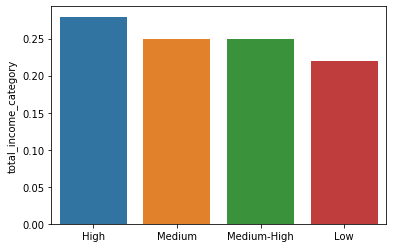

```python
sns.barplot(x=dd['total_income_category'].unique().tolist(), y=dd['total_income_category'].value_counts(normalize=True))
```

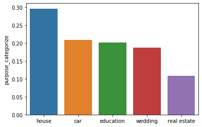

```python
sns.barplot(x=dd['purpose_categorize'].unique().tolist(), y=dd['purpose_categorize'].value_counts(normalize=True))
```

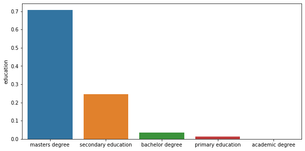

```python
f, ax = plt.subplots(1,1)
f.set_figheight(5)
f.set_figwidth(10)
sns.barplot(x=dd['education'].unique().tolist(), y=dd['education'].value_counts(normalize=True))
```

### Conclusion

```python
dd.head(2)
```

|  | children | dob_years | education | family_status | gender | income_type | debt | total_income | purpose | purpose_categorize | total_income_category |
| --- | --- | --- | --- | --- | --- | --- | --- | --- | --- | --- | --- |
| 0 | 1.0 | 42.0 | masters degree | married | F | employee | 0 | 253875.639453 | purchase of the house | house | High |
| 1 | 1.0 | 36.0 | secondary education | married | F | employee | 0 | 112080.014102 | car purchase | car | Medium |

I have dropped two columns and created a dictionary so I do not lose information. Both dropped column had the same meaning as other column so I did not need to keep it.  
About purpose column I have decided to categorized it into 6 groups: house, real estate, car, education, wedding and other.  
After counting the values I can tell that I might have caught all of the groups (no 'other' group).  
I also decided to create a category column from the total_income for later use.

### Step 3. Answer these questions

- Is there a relation between having kids and repaying a loan on time?

```python
dd[(dd['children'] >0) & (dd['debt'] == 0)].shape[0] / dd[dd['children'] >0].shape[0]
```

```
0.9074630945872061
```

### Conclusion

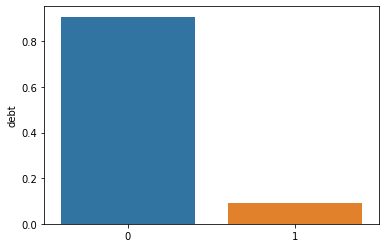

```python
sns.barplot(x=[0,1], y=dd[dd['children'] >0]['debt'].value_counts(normalize=True))
```

90% of the customers that have children pay theirs debt!

- Is there a relation between marital status and repaying a loan on time?

```python
for status in family_status_dict.values():
    perc = dd[(dd['family_status'] == status) & (dd['debt'] == 0)].shape[0] / dd[(dd['family_status'] == status)].shape[0]
    print('{:.2%} of the family status {} have paid theirs loans'.format(perc,status))
```

```
92.45% of the family status married have paid theirs loans
90.65% of the family status civil partnership have paid theirs loans
93.43% of the family status widow / widower have paid theirs loans
92.89% of the family status divorced have paid theirs loans
90.25% of the family status unmarried have paid theirs loans
```

### Conclusion

I can tell that at least of 90% for every family status pay back theirs loan. I can conclude that there is no relation between family status and repaying back the loan.

- Is there a relation between income level and repaying a loan on time?

```python
for status in set(dd['total_income_category']):
    perc = dd[(dd['total_income_category'] == status) & (dd['debt'] == 0)].shape[0] / dd[(dd['total_income_category'] == status)].shape[0]
    print('{:.2%} of income level {} have paid theirs loans'.format(perc,status))
```

```
92.86% of income level High have paid theirs loans
91.22% of income level Medium have paid theirs loans
91.40% of income level Medium-High have paid theirs loans
92.04% of income level Low have paid theirs loans
```

### Conclusion

As I can see, it does not matter what is the income level of a customer, 90% of the times they pay it back.

- How do different loan purposes affect on-time repayment of the loan?

```python
for status in set(dd['purpose_categorize']):
    perc = dd[(dd['purpose_categorize'] == status) & (dd['debt'] == 0)].shape[0] / dd[(dd['purpose_categorize'] == status)].shape[0]
    print('{:.2%} of purpose category {} have paid theirs loans'.format(perc,status))
```

```
92.47% of purpose category real estate have paid theirs loans
92.00% of purpose category wedding have paid theirs loans
90.64% of purpose category car have paid theirs loans
90.78% of purpose category education have paid theirs loans
92.97% of purpose category house have paid theirs loans
```

### Step 4. General conclusion

In order to get a General conclusion I will investigate a little the group the did not repay theirs loan.

```python
did_not_pay = dd[dd['debt'] == 1]
did_not_pay.shape
```

```
(1741, 11)
```

```python
did_not_pay.head(2)
```

|  | children | dob_years | education | family_status | gender | income_type | debt | total_income | purpose | purpose_categorize | total_income_category |
| --- | --- | --- | --- | --- | --- | --- | --- | --- | --- | --- | --- |
| 14 | 0.0 | 56.0 | masters degree | civil partnership | F | partner | 1 | 165127.911772 | buy residential real estate | real estate | Medium-High |
| 32 | 0.0 | 34.0 | secondary education | civil partnership | F | employee | 1 | 139057.464207 | having a wedding | wedding | Medium |

```python
did_not_pay.describe(include=['object'])
```

|  | education | family_status | gender | income_type | purpose | purpose_categorize | total_income_category |
| --- | --- | --- | --- | --- | --- | --- | --- |
| count | 1741 | 1741 | 1741 | 1741 | 1741 | 1741 | 1741 |
| unique | 4 | 5 | 2 | 6 | 38 | 5 | 4 |
| top | secondary education | married | F | employee | having a wedding | house | Medium-High |
| freq | 1364 | 931 | 994 | 1061 | 64 | 446 | 516 |

After my investigation of the data I conclude that neither the customers martial status nor his number of children have an impact of his will to repay his debt.  
None of the variable that were inspected had a blurry conclusion, it was determined that every one paid theirs debt (more than 90% for each inspected case).

Overall I can not see a reason not to let a customer have a loan, after checking overall info about those who did not repay back, there is nothing that standsout.  
Other than that I would have to run some decision tree algorithm or logistic regression to find a pattern.